# Prediction Assignment Writeup

CK

19 April 2019

## Synopsis

Using devices such as Jawbone Up, Nike FuelBand, and Fitbit it is now possible to collect a large amount of data about personal activity. In this project, data from accelerometers on the belt, forearm, arm, and dumbell of 6 participants were used. They were asked to perform barbell lifts correctly and incorrectly in 5 different ways (“classe” variable in the dataset). More information is available from the website here: http://groupware.les.inf.puc-rio.br/har (see the section on the Weight Lifting Exercise Dataset). The goal of the project is to predict the manner (“classe) in which the participants did the exercise.

## Data

The training data downloaded from: https://d396qusza40orc.cloudfront.net/predmachlearn/pml-training.csv

The test data downloaded from: https://d396qusza40orc.cloudfront.net/predmachlearn/pml-testing.csv

```r
TrainUrl    <- "https://d396qusza40orc.cloudfront.net/predmachlearn/pml-training.csv"
TestUrl     <- "https://d396qusza40orc.cloudfront.net/predmachlearn/pml-testing.csv"
TrainFile   <- "pml-traininig.csv"
TestFile    <- "pml-testing.csv"

# download the datasets
download.file(TrainUrl,destfile = TrainFile)
training <- read.csv(TrainFile)

download.file(TestUrl,destfile = TestFile)
testing  <- read.csv(TestFile)
```

## R Libraries

List of libraries utilised

```r
library(dplyr)
library(ggplot2)
library(caret)
```

## Cleaning data

```r
dim(training)
```

```
## [1] 19622   160
```

```r
dim(testing)
```

```
## [1]  20 160
```

```r
trainnacols <- sapply(training,function(x)all(any(is.na(x))))
trainnanames<- names(training[,trainnacols])
testnacols  <- sapply(testing,function(x)all(any(is.na(x))))
testnanames<- names(testing[,testnacols])
```

There are large number of columns with no data in both training dataset: **67** and testing dataset: **100**. Since both dataset must have same columns, all columns with NA will be removed from both datasets. Also, first 7 columns are a running number, user specific data and timestamps which are not relevant for this project therefore will be removed from both training and test dataset.

```r
allnacol <- (trainnacols+testnacols>0)
trainclean <- training[,!names(training) %in% trainnanames]
trainclean <- trainclean[,!names(trainclean) %in% testnanames]

testclean <- testing[,!names(testing) %in% trainnanames]
testclean <- testclean[,!names(testclean) %in% testnanames]

# Remove unnecessary columns
notReqCol <- names(training[,1:7])
trainclean <- trainclean[,!names(trainclean) %in% notReqCol]
testclean <- testclean[,!names(testclean) %in% notReqCol]

dim(trainclean)
```

```
## [1] 19622    53
```

```r
dim(testclean)
```

```
## [1] 20 53
```

## Exploratory Analysis

Now some exploratory analysis:

```r
freqClasse <- cbind(table(trainclean$classe),round(prop.table(table(trainclean$classe))*100,2))

colnames(freqClasse) <- c('Count','Percentage')

freqClasse
```

```
##   Count Percentage
## A  5580      28.44
## B  3797      19.35
## C  3422      17.44
## D  3216      16.39
## E  3607      18.38
```

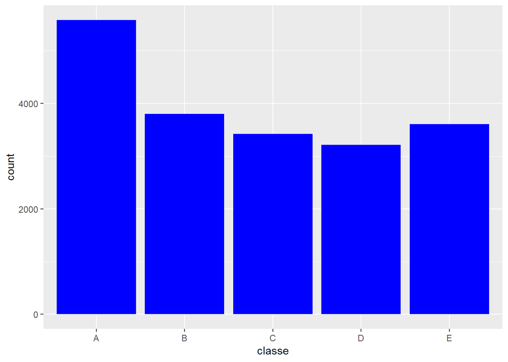

```r
ggplot(trainclean, aes(classe)) +
    geom_bar(fill = "blue")
```

## Prediction Model Building

Partition the training dataset 70/30 ratio, 30% used for testing

```r
set.seed(1234)

inTrain  <- createDataPartition(trainclean$classe, p=0.7, list=FALSE)
TrainSet <- trainclean[inTrain, ]
TestSet  <- trainclean[-inTrain, ]
```

### Cross validation

For this project K-Fold Cross validation with k=3 is used. K-Fold is a robust method for estimating accuracy,

```r
# define training control
trCtrl <- trainControl(method="cv", number=3, verboseIter=FALSE)
metrc <- "Accuracy"
```

### Prediction Model Selection

**Random Forest (“rf”)**

```r
set.seed(1234)
fitrf  <- train(classe~., data=TrainSet, method="rf", metric=metrc, trControl=trCtrl, ntree=200)
predrf <- predict(fitrf, TestSet)
confrf <- confusionMatrix(predrf, TestSet$classe)
```

**Boosted Trees (“gbm”)**

```r
set.seed(1234)
fitgbm  <- train(classe~., data=TrainSet, method="gbm", metric=metrc, trControl=trCtrl, verbose=FALSE)
predgbm <- predict(fitgbm, TestSet)
confgbm <- confusionMatrix(predgbm, TestSet$classe)
```

**Linear Discriminant Analysis (“lda”)**

```r
set.seed(1234)
fitlda  <- train(classe~., data=TrainSet, method="lda", metric=metrc, trControl=trCtrl)
predlda <- predict(fitlda, TestSet)
conflda <- confusionMatrix(predlda, TestSet$classe)
```

Compare accuracy and Out of sample error of each model to determine the model to be used

```r
accur   <- data.frame(confrf$overall[1],confgbm$overall[1],conflda$overall[1])
accur   <- rbind(accur, c(1-confrf$overall[1],1-confgbm$overall[1],1-conflda$overall[1]))
colnames(accur)     <-c('RF', 'GBM','LDA')
rownames(accur)[2]  <-"Out of Sample Error"
accur
```

```
##                              RF        GBM       LDA
## Accuracy            0.994392523 0.96431606 0.7048428
## Out of Sample Error 0.005607477 0.03568394 0.2951572
```

From the table above, model created with **Random Forest (RF) algorithm** provided most accuracy, therefore, it is selected for the predictions.

## Prediction

```r
set.seed(1234)
predictions <- predict(fitrf, testclean)
tblPredict <- data.frame(matrix(predictions, testclean$problem_id))
colnames(tblPredict) <- testclean$problem_id
rownames(tblPredict) <- "Predictions"
tblPredict
```

```
##             1 2 3 4 5 6 7 8 9 10 11 12 13 14 15 16 17 18 19 20
## Predictions B A B A A E D B A  A  B  C  B  A  E  E  A  B  B  B
```

## Conclusion

After cleaning the data as explained in Cleaning data, three different algorithms were explored using cross validation. **Random Forest** had the highest accuracy and of course lowest out of Sample Error, therefore model developed with RF was utilised to predict the “classe” for each observation in the testing dataset. Note of caution: Random Forest algorithm has a high computational cost.

## Citations

The data for this project was sourced from: http://web.archive.org/web/20161224072740/http:/groupware.les.inf.puc-rio.br/har. Gratefully acknowledge the generosity of them by allowing their data to be used for this assignment.